# nyc_bikes a glimpse

Juan Ignacio De Vicente

2022-11-14

| bike_id | start_time | stop_time | start_station | start_lat | start_long | end_station | end_lat | end_long | type | birth_year | gender | day | month | label | abbr | year | age |
| --- | --- | --- | --- | --- | --- | --- | --- | --- | --- | --- | --- | --- | --- | --- | --- | --- | --- |
| 26301 | 2018-02-26 19:11:03.707 | 2018-02-26 19:15:40.805 | 3186 | 40.71959 | -74.04312 | 3203 | 40.72760 | -74.04425 | Subscriber | 1986 | Male | 26 | 2 | TRUE | FALSE | 2018 | 32 |
| 26301 | 2018-02-27 07:52:49.151 | 2018-02-27 07:58:13.075 | 3203 | 40.72760 | -74.04425 | 3202 | 40.72722 | -74.03376 | Subscriber | 1979 | Male | 27 | 2 | TRUE | FALSE | 2018 | 39 |
| 26301 | 2018-02-27 12:03:27.595 | 2018-02-27 12:04:54.122 | 3202 | 40.72722 | -74.03376 | 3638 | 40.72429 | -74.03548 | Subscriber | 1963 | Male | 27 | 2 | TRUE | FALSE | 2018 | 55 |
| 26301 | 2018-02-27 13:53:51.996 | 2018-02-27 14:21:04.941 | 3638 | 40.72429 | -74.03548 | 3638 | 40.72429 | -74.03548 | Subscriber | 1984 | Male | 27 | 2 | TRUE | FALSE | 2018 | 34 |
| 26301 | 2018-02-27 14:30:42.846 | 2018-02-27 14:33:11.381 | 3638 | 40.72429 | -74.03548 | 3187 | 40.72112 | -74.03805 | Subscriber | 1980 | Male | 27 | 2 | TRUE | FALSE | 2018 | 38 |
| 26301 | 2018-02-27 16:31:04.002 | 2018-02-27 16:33:27.957 | 3187 | 40.72112 | -74.03805 | 3638 | 40.72429 | -74.03548 | Subscriber | 1980 | Male | 27 | 2 | TRUE | FALSE | 2018 | 38 |
| 26301 | 2018-02-27 17:37:12.585 | 2018-02-27 17:40:49.578 | 3638 | 40.72429 | -74.03548 | 3639 | 40.71925 | -74.03423 | Subscriber | 1989 | Male | 27 | 2 | TRUE | FALSE | 2018 | 29 |
| 26301 | 2018-02-27 17:49:10.130 | 2018-02-27 17:55:03.029 | 3639 | 40.71925 | -74.03423 | 3202 | 40.72722 | -74.03376 | Subscriber | 1962 | Male | 27 | 2 | TRUE | FALSE | 2018 | 56 |
| 26301 | 2018-02-27 18:21:57.963 | 2018-02-27 18:25:18.165 | 3202 | 40.72722 | -74.03376 | 3638 | 40.72429 | -74.03548 | Subscriber | 1992 | Male | 27 | 2 | TRUE | FALSE | 2018 | 26 |
| 26301 | 2018-02-27 22:08:55.335 | 2018-02-27 22:28:42.461 | 3638 | 40.72429 | -74.03548 | 3281 | 40.74591 | -74.05727 | Subscriber | 1981 | Male | 27 | 2 | TRUE | FALSE | 2018 | 37 |

[output cut: 4258 more lines]

Business questions In your report, please consider the following questions:

What is the pattern of bike hires over time (e.g. within a year, month, week, or day)? Do bike hire patterns differ between bike rider demographics? (e.g. gender, type of trip, age) Any other insights? social balance company, how to improve

# INTRODUCTION

City Bike is the social company of New York City in charge to develop a more suitable, helthier and eco-friendly transport through the use of bikes. The project started in 2011 but its public appeared was in 2013 and thanks to the amazing and positive reception from the public we have been growing not only in numbers of users but also in bikes and area covered for the service. This report shows a glimpse of our data set for 2018, although is a sample we think we are able to get some conclusions in order to improve the business

### What we offer

We offer a diverse range of options tailored to different necessities.From an Annual Membership with unlimited rides of 45 minutes max to single ride of 30 minutes or a day pass (24 hours and unlimited 30 minutes rides). Obviously the prices are slightly different,and always there will be an increment of the final fee if the time is overtaken.

### Data sample from our registers in 2018. What can we learn from it?

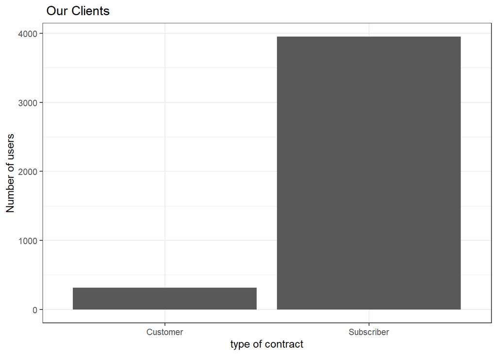

In 2018, most of our users and subscribers were male. we should ask why the quantity of women were much less, possible internal factors from our service as the kind of bike(weight,area covered, period of rides, basket or transport kids), external factors, like the traffic, different ways of journey.

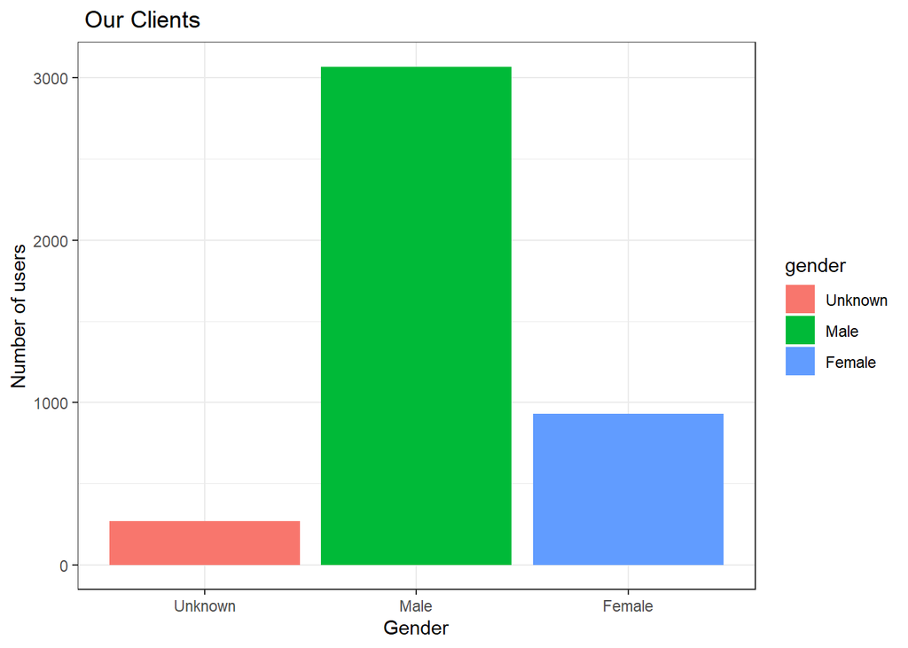

Only, the unknown gender were majority in the customers section. There are multiple answers but the probably answer was related they are very casual users and it was unclear for them why we ask them for their gender.

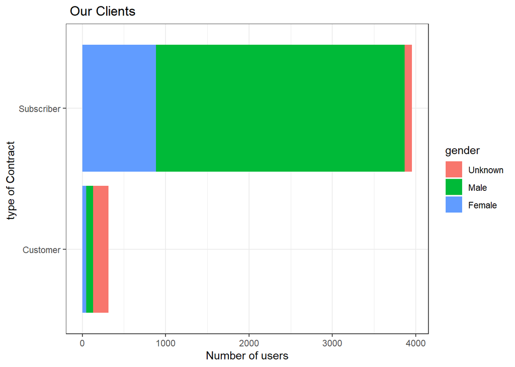

In general, it is complicate to see and speak about clear patterns in the use of our service per days or per month. There are several fundamental variables outside of the control of the business and they have a clear implication in the behavior of our customers like weather, traffic,accidents or impossible access to the stations or even vandalized.

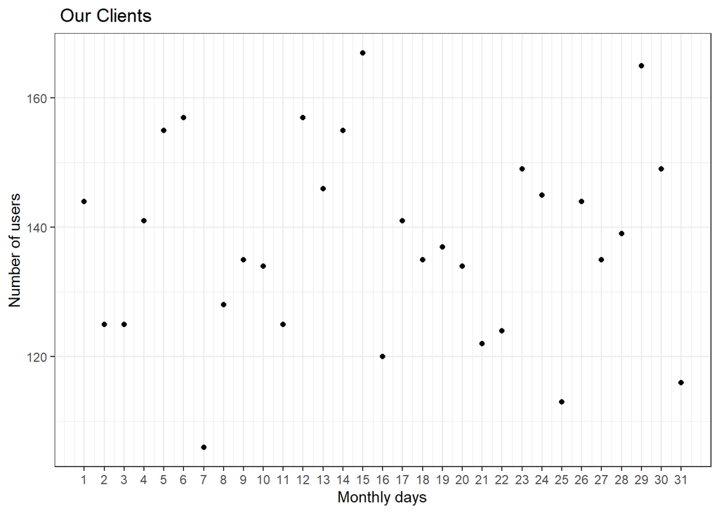

In this graphic, we did an assumption that all the days were the same in any month. As we can see that most of the days we have between 120 and 160 users and some specific days we have a bit more or less.

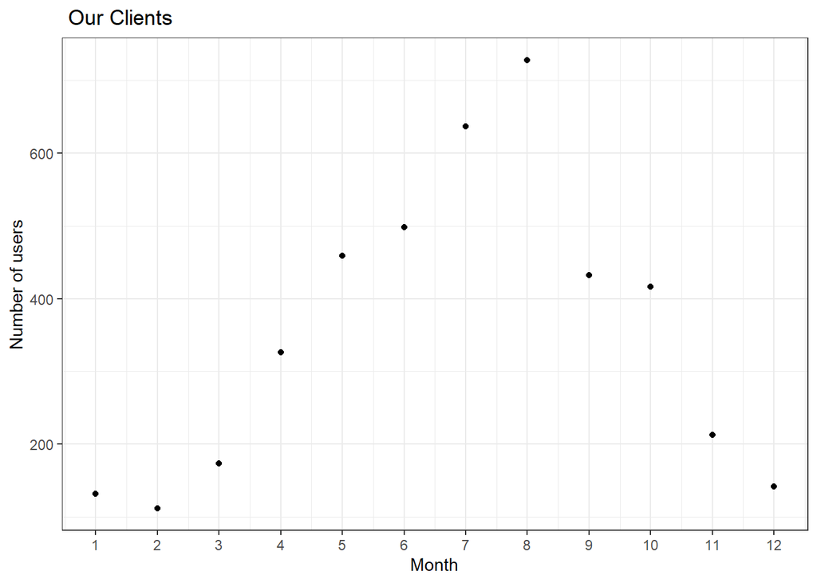

As we mention before the weather, we can see in the year 2018 there were a clear relation between a nice temperature and number of users. We can assume that every year will be similar. Same result, different visualization.

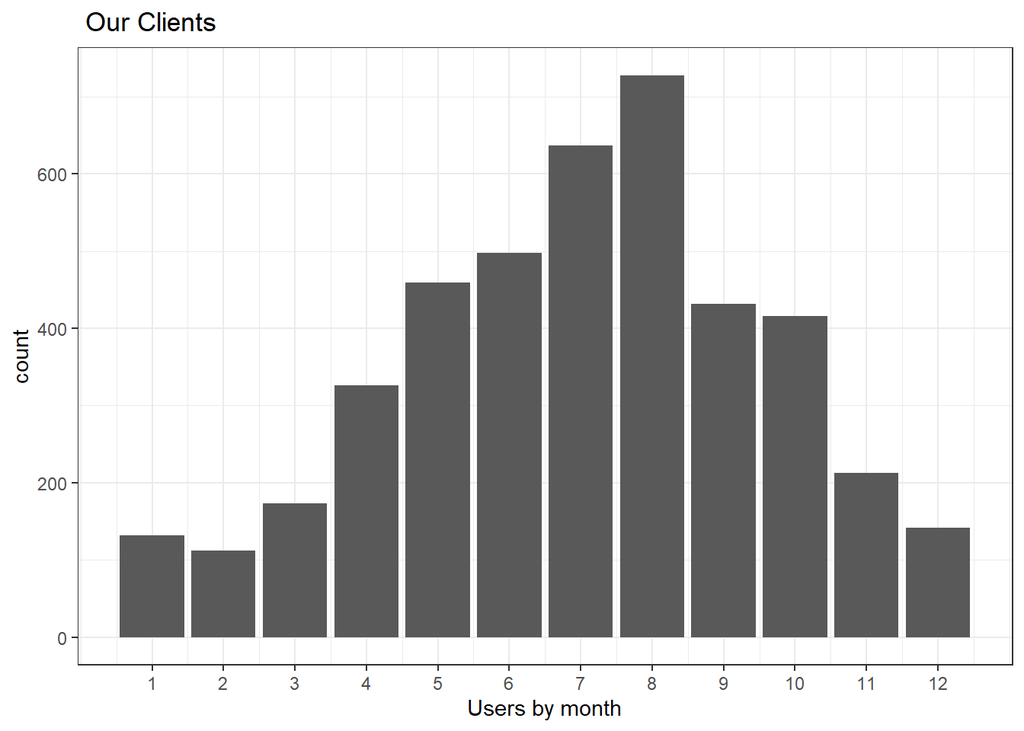

### How are our clients

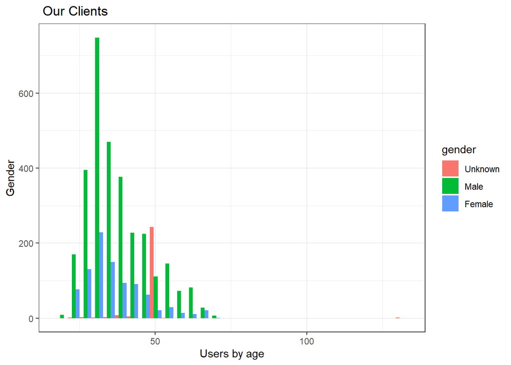

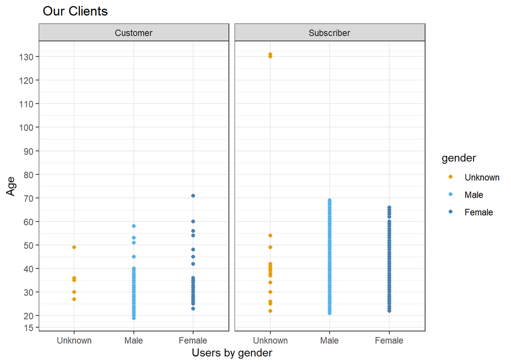

### Where are our stations?

This plot shows that we are covering a big area of and New York, but is still possible to expand the service to others areas.

```r
leaflet(nyc_bikes_df) %>%
  addTiles() %>%
  addCircleMarkers(lng =~ start_long,
             lat =~ start_lat,radius = ~ start_station/5 ,weight = 1)
```

[interactive chart not shown]

### Recommendations/ Conclusions

Because of fact that with have wrong data (at least,age) from few subscribers, we have to meliorate our register system. The number of subscribers in relation with customers is minimum so, at the moment it is not a problem. We have to think if we ant to expand the service to other parts of New York/ New Jersey with more stations or prioritize the user experience/ satisfaction and attract more female.

### Question?

Bikes is for sharing so obviusly there will be extra fees if the time is overtaken prices : Day pass 24H 15 dollars, Annual Membership is 15$ monthly or 185!dollars if billed upfront annually and 3.50 dollars for a single ride